# Applying Machine Learning to Bitcoin Price Prediction

Tshering Wangchuk & Aaron Salot

12/08/2021

# Introduction

Bitcoin, and other cryptocurrencies, have been present for over a decade, and have become increasingly prevalent in the global economic system. Bitcoin, the first and most widely used cryptocurrency, is used as a store of value, tradable asset, and a form of currency. This analysis aims to take advantage of the open-source blockchain network behind Bitcoin, and our goal is to understand the various factors that influence the price movement of Bitcoin.

Bitcoin popularized blockchain technology, and Satoshi Nakamoto used it to solve the Byzanztine’s General Problem and the double-spending problem without the need of a central authority. It is also the fastest growing asset class to have reached close to $2-3 trillion in market capitalization in over a decade. Given the recent technological adoption as seen with Tesla, Microstrategy & El Salvador’s government, we are particularly interested to examine the price movement of Bitcoin by looking at certain variables that are publically accessible through Bitcoin’s public ledger.

# Data Sources

We used three different data sources: CoinMetrics, Glassnodes & FRED. We collected an overall of 162 variables with over 4000 observations; however, after basic explanatory analysis and cleaning, we ended up with 88 variables and 2,100 observations. CoinMetrics was the largest bulk of our data, where we used their public API to extract daily data from 2010 to present (November, 2021). We also secured a Glassnodes membership that gave access to daily changes in select variables not present in the CoinMetrics API. Taking from the previous literature review, we also decided to incorporate certain variables that have been examined in previous papers - CPI, Gold Price, Nasdaq & Bitcoin Google Search trends.

# Global Interpretation of ML Models

## Model Performance

```
## Preparation of a new explainer is initiated
##   -> model label       :  Lasso
##   -> data              :  1608  rows  26  cols
##   -> data              :  tibble converted into a data.frame
##   -> target variable   :  1608  values
##   -> predict function  :  yhat.workflow  will be used (  default  )
##   -> predicted values  :  No value for predict function target column. (  default  )
##   -> model_info        :  package tidymodels , ver. 0.1.4 , task classification (  default  )
##   -> predicted values  :  numerical, min =  0.09533178 , mean =  0.5379356 , max =  0.951647
##   -> residual function :  difference between y and yhat (  default  )
##   -> residuals         :  numerical, min =  0.04835297 , mean =  0.9999997 , max =  1.827969
##   A new explainer has been created!
```

```
## Preparation of a new explainer is initiated
##   -> model label       :  rf
##   -> data              :  1608  rows  26  cols
##   -> data              :  tibble converted into a data.frame
##   -> target variable   :  1608  values
##   -> predict function  :  yhat.workflow  will be used (  default  )
##   -> predicted values  :  No value for predict function target column. (  default  )
##   -> model_info        :  package tidymodels , ver. 0.1.4 , task classification (  default  )
##   -> predicted values  :  numerical, min =  0 , mean =  0.5449938 , max =  1
##   -> residual function :  difference between y and yhat (  default  )
##   -> residuals         :  numerical, min =  0.4 , mean =  0.9929415 , max =  1.75
##   A new explainer has been created!
```

```
## Preparation of a new explainer is initiated
##   -> model label       :  tree
##   -> data              :  1608  rows  26  cols
##   -> data              :  tibble converted into a data.frame
##   -> target variable   :  1608  values
##   -> predict function  :  yhat.workflow  will be used (  default  )
##   -> predicted values  :  No value for predict function target column. (  default  )
##   -> model_info        :  package tidymodels , ver. 0.1.4 , task classification (  default  )
##   -> predicted values  :  numerical, min =  0.1351351 , mean =  0.5379353 , max =  0.6923077
##   -> residual function :  difference between y and yhat (  default  )
##   -> residuals         :  numerical, min =  0.3076923 , mean =  1 , max =  1.864865
##   A new explainer has been created!
```

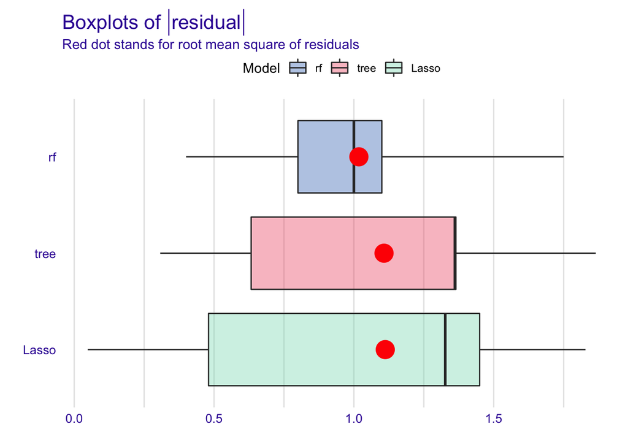

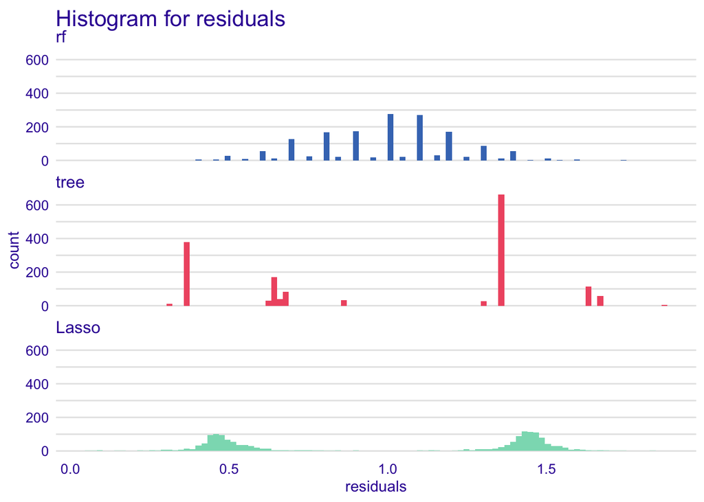

## Variable Importance

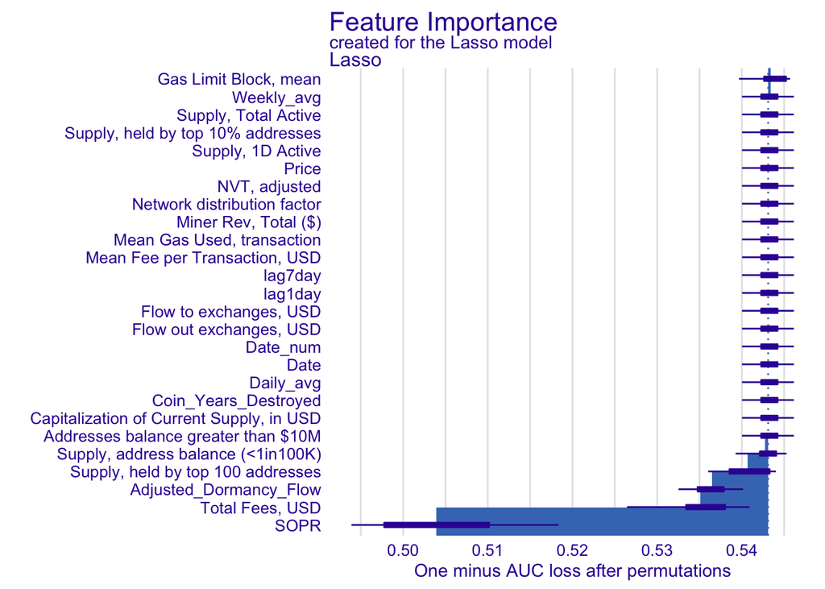

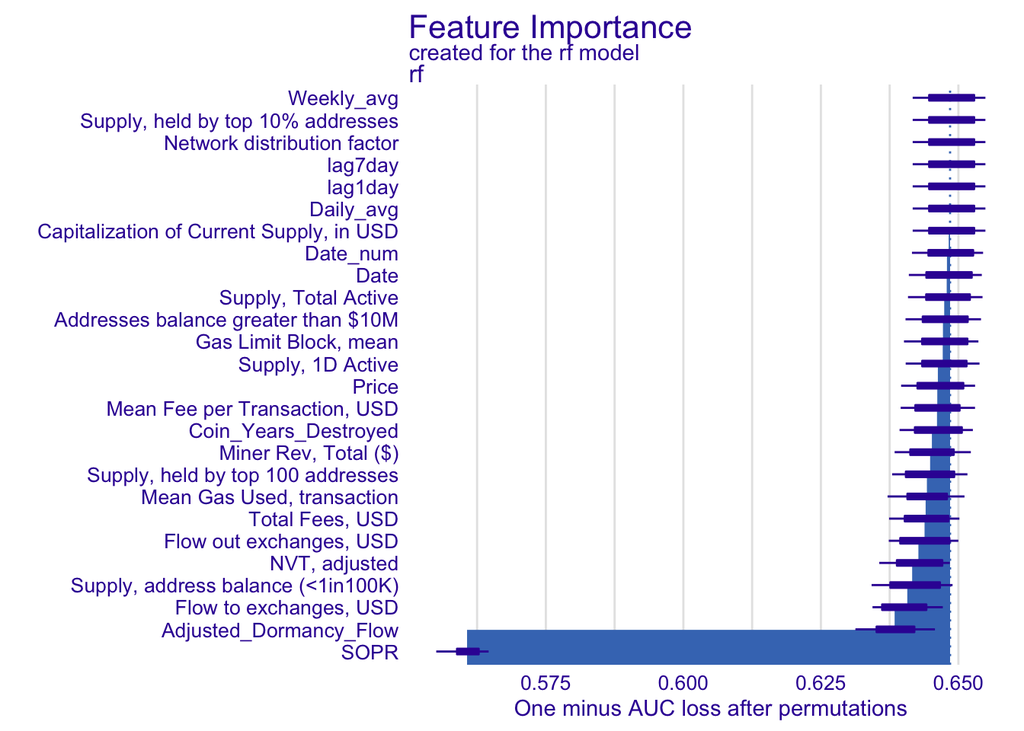

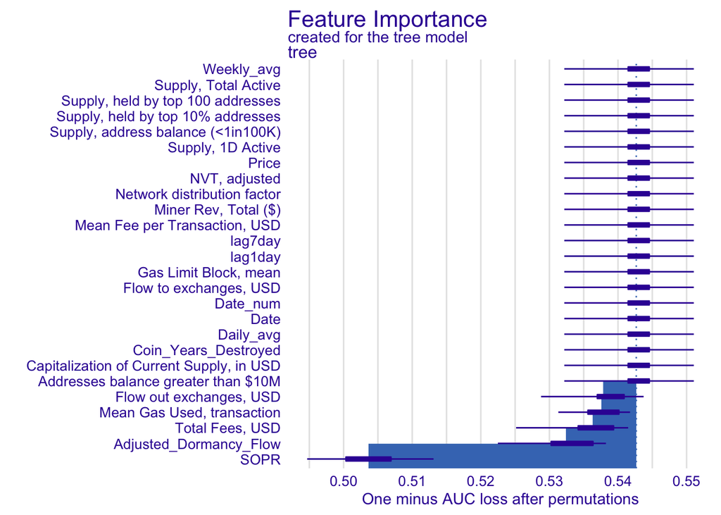

## Ceteris-Paribus Profile

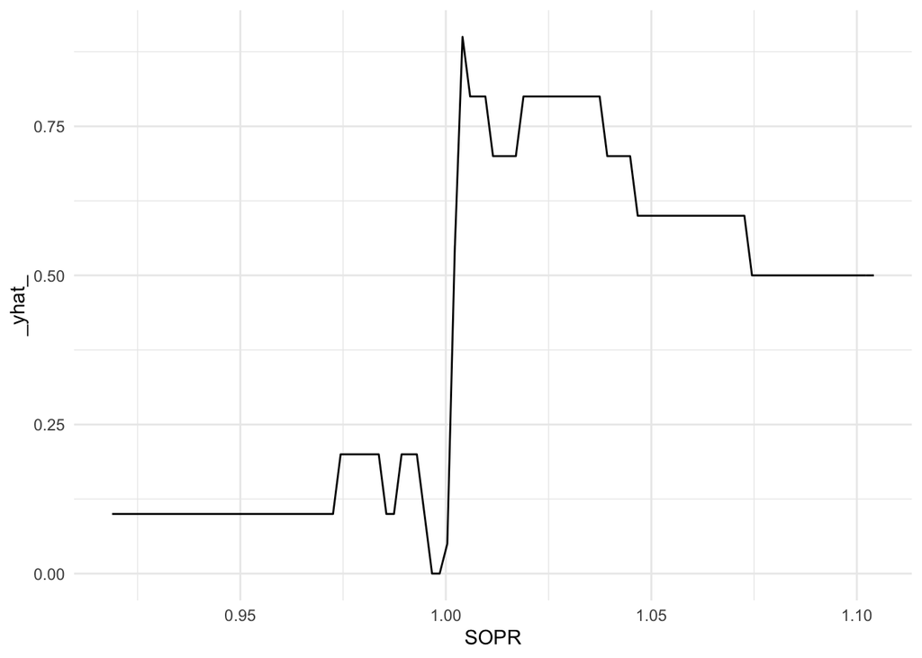

## Partial Dependence Plots

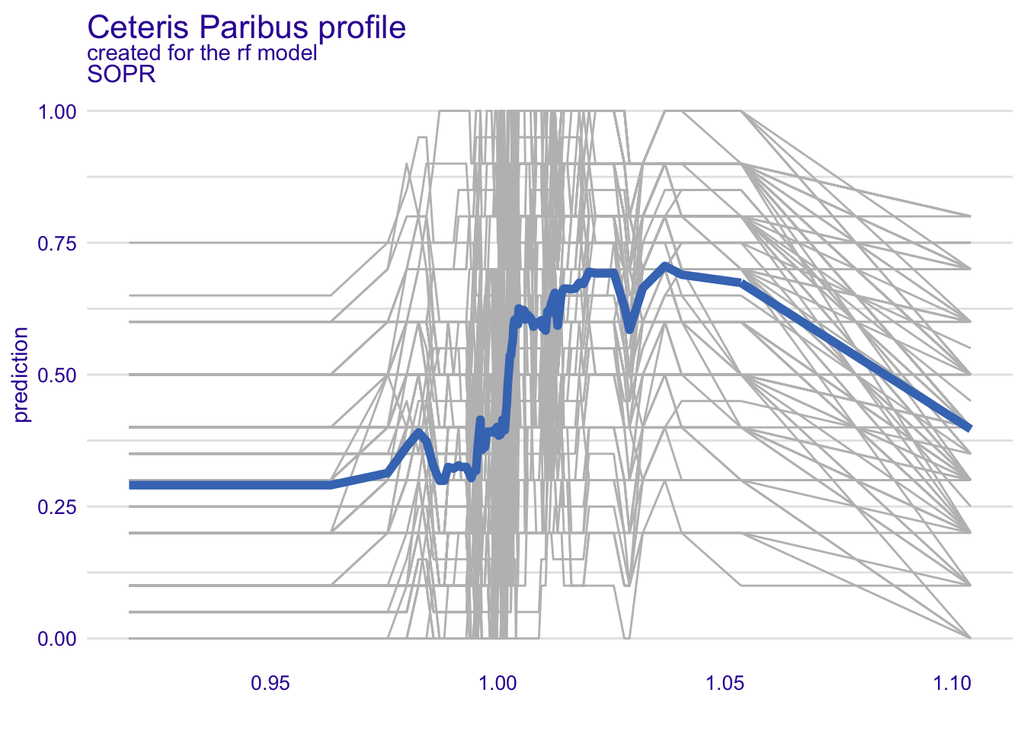